# Modeling and Uncertainty

   We’ll start with the second issue, because it’s easier to address. Of course, we’ll need to answer the first before trusting this model.

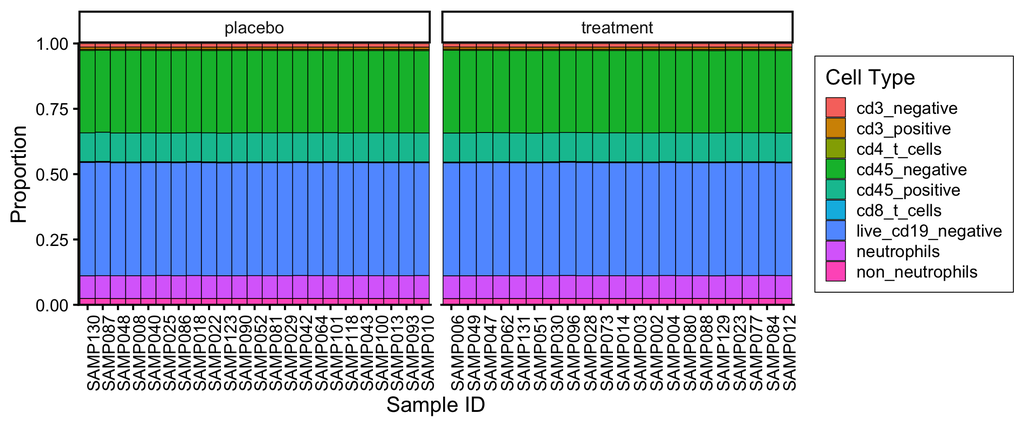

   ```r
   m <- fit_cytof(proportion ~ 1)
   counts <- simulate_counts(m)
   plot_counts(counts)
   ```

8. **Revised Models.** To let cell-type proportions depend on treatment, we modify the formula from `proportion ~ 1` to `proportion ~ arm`.

   ```r
   m <- fit_cytof(proportion ~ arm)
   ```

9. The estimated coefficients with treatment status as a covariate are printed below. The row for `cd3_negative` means that placebo samples have about `plogis(-3.98) = 0.018` of their composition from CD3- cells. Under treatment this decreases to about `plogis(-3.98 - 0.578) = 0.010`.

   ```r
   coef_df <- map_dfr(m, coef, .id = "cell_type")
   coef_df
   ```

   ```
   # A tibble: 9 × 3
     cell_type          `(Intercept)` armtreatment
     <chr>                      <dbl>        <dbl>
   1 live_cd19_negative        -0.283      0.0207
   2 cd45_negative             -0.773     -0.00320
   3 cd45_positive             -2.11       0.0531
   4 neutrophils               -2.48       0.221
   5 non_neutrophils           -3.45      -0.513
   6 cd3_negative              -3.98      -0.578
   7 cd3_positive              -4.54      -0.444
   8 cd4_t_cells               -5.18      -0.482
   9 cd8_t_cells               -5.66      -0.338
   ```

   We could in principle interpret changes in composition due to treatment from this model. But we shouldn’t trust this model yet because it still fails to account for sample-to-sample variability.

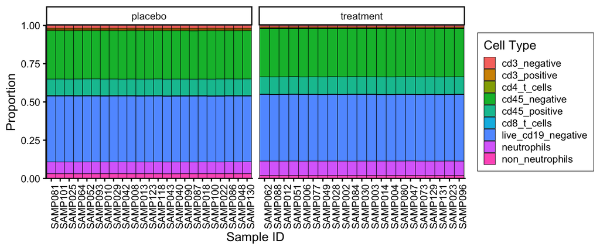

   ```r
   counts <- simulate_counts(m)
   plot_counts(counts)
   ```

10. To account for sample-to-sample differences, we add a random effect. Since the sample labels are kept in the `sample_id` column, we modify the formula to

    ```
     proportion ~ arm + (1 | sample_id)
    ```

    and switch from `glm` to `glmer`.
11. The new simulated data are much more realistic. They still don’t quite have the smooth variation in composition across samples seen in the real data – this could be introduced through latent factors or modeling correlation across cell types. Even so, the current model is often sufficient for real data analyses, and underlies the `diffcyt` Bioconductor package Weber et al. (2019).

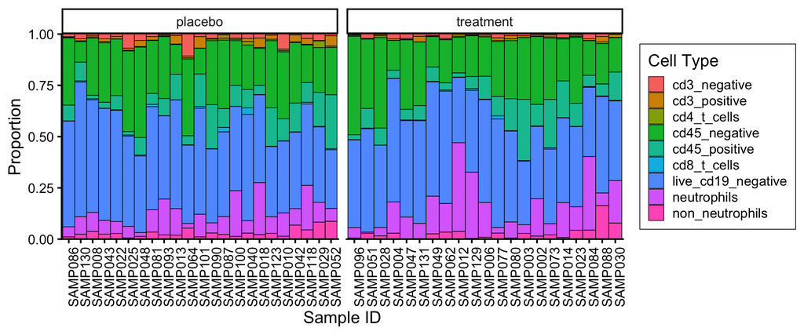

    ```r
    fits <- fit_cytof(proportion ~ arm + (1 | sample_id), glmer)
    counts <- simulate_counts(fits)
    plot_counts(counts)
    ```

12. The model output shows how the treatment affects each cell type (`armtreatment`) and how much it varies across sample (`sample_id` `Std. Dev`). For example, under treatment the CD3- composition tends to decrease relative to the other cell types.

    ```r
    summary(fits[["cd3_negative"]])
    ```

    ```
    Generalized linear mixed model fit by maximum likelihood (Laplace
      Approximation) [glmerMod]
     Family: binomial  ( logit )
    Formula: proportion ~ arm + (1 | sample_id)
       Data: flow2
    Weights: total

          AIC       BIC    logLik -2*log(L)  df.resid
        928.7     934.0    -461.3     922.7        41

    Scaled residuals:
          Min        1Q    Median        3Q       Max
    -0.129244 -0.003768  0.002199  0.006118  0.011028

    Random effects:
     Groups    Name        Variance Std.Dev.
     sample_id (Intercept) 1.117    1.057
    Number of obs: 44, groups:  sample_id, 44

    Fixed effects:
                 Estimate Std. Error z value Pr(>|z|)
    (Intercept)   -4.2288     0.2204 -19.188   <2e-16 ***
    armtreatment  -0.6108     0.3190  -1.915   0.0555 .
    ---
    Signif. codes:  0 '***' 0.001 '**' 0.01 '*' 0.05 '.' 0.1 ' ' 1

    Correlation of Fixed Effects:
                (Intr)
    armtreatmnt -0.691
    ```

    *Exercise: According to the fitted model, what is the typical proportion of CD3- cells in the control and treatment groups? Hint: Use the `plogis` function applied to the right choice of values under `Estimate`.*

## References

Weber, Lukas M., Malgorzata Nowicka, Charlotte Soneson, and Mark D. Robinson. 2019. “Diffcyt: Differential Discovery in High-Dimensional Cytometry via High-Resolution Clustering.” *Communications Biology* 2 (1). https://doi.org/10.1038/s42003-019-0415-5.

## Footnotes

[^1]: The technical reason is that the Bernoulli distribution is a special case of the binomial when the total count parameter is set to 1.
[^2]: Because they are given on the log-odds scale. The model estimation algorithm works on this scale because it isn’t constrained to $\left[0, 1\right]$, and so general-purpose optimization methods can be used.